# Scholarship Data Exploration

Paul Hively

August 4, 2016

Source available [here](https://github.com/phively/gsb-scholarship/blob/master/1%20data%20exploration.Rmd).

The goal of this project is to identify covariates and factors associated with scholarship funds. A predictive model would be nice, but for now my main focus is explanation.

Load the libraries and data and do some cleanup.

```r
source("LIBRARIES.R")
dat <- read.csv("data\\2016-08-09 ABEM FY17.csv", header=T, stringsAsFactors=F)

## Data cleanup
mdat <- dat %>%
  # Select desired columns
  select(student.gifts = Giving.Student.Support,
         id = Entity.ID,
         deg.year = Booth.ClassYr.or.RecYr,
         deg.prg = Booth.Program.Group,
         employ.yrs = Employ.Years.At.Current.Company,
         nice.title = Bus.Title.High.Lvl,
         gift.cap = Gift.Capacity.Numerical.Amt..CR.,
         fys.giving = Giving.FYs.of.Giving,
         fys.recent = Giving.FY.in.Last.5,
         first.gift = Giving.First.Trans.Amt,
         af.gifts = Giving.Booth.AF.Gifts,
         lt.giving = Booth.Lifetime.Giving,
         spouse = Spouse.Married.UC.Booth,
         known.to = Rel.Known.Tos.Count,
         stewardee = Alloc.Stewardee.Student.Support,
         committees = Committee.in.Last.3.FY,
         vols = Vol.Acts..BUS.,
         speak = Events.Vol.Speaker,
         stu.acts = Student.Acts..BUS.,
         lead.facil = Student.Acts.LEAD.Facilitator,
         stu.supp = Vol.Act.Student.Supporter,
         scholarship = Scholarships.Count,
         events = Events.Attended..BUS.,
         events.stu = Events.Attended..BUS..Student,
         nonprofit = Nonprofit.Leadership.Flag) %>%
  # Drop null rows
  filter(!is.na(id)) %>%
  # Convert string columns to factor
  mutate(deg.prg = as.factor(deg.prg) %>% relevel("Full-Time"),
         spouse = as.factor(spouse)) %>%
  # Convert currency columns to numeric
  CurrencyToNumeric(fields = c("student.gifts", "gift.cap", "first.gift", "lt.giving")) %>%
  # Exclude non-alumni
  filter(deg.prg != '')
# Replace NAs with 0
mdat[is.na(mdat)] <- 0

# View random sample of resulting data
set.seed(123)
rand <- sample(1:nrow(mdat), nrow(mdat))
mdat %>% select(-id) %>% slice(rand) %>% str()
```

```
## 'data.frame':    57465 obs. of  24 variables:
##  $ student.gifts: num  0 0 0 0 0 0 0 0 0 0 ...
##  $ deg.year     : int  1991 1999 1994 1999 2004 1983 2002 1968 2005 1946 ...
##  $ deg.prg      : Factor w/ 6 levels "Full-Time","",..: 1 5 1 3 5 5 5 3 5 1 ...
##  $ employ.yrs   : int  0 7 22 19 11 24 0 0 1 0 ...
##  $ nice.title   : int  1 0 0 0 0 0 1 0 0 0 ...
##  $ gift.cap     : num  0 0 0 0 0 0 0 0 0 0 ...
##  $ fys.giving   : num  0 0 0 0 0 0 2 14 10 17 ...
##  $ fys.recent   : num  0 0 0 0 0 0 0 0 4 0 ...
##  $ first.gift   : num  0 0 0 0 0 0 200 10 100 10 ...
##  $ af.gifts     : num  0 0 0 0 0 0 1 5 1 3 ...
##  $ lt.giving    : num  0 0 0 0 0 0 400 1660 1400 150 ...
##  $ spouse       : Factor w/ 4 levels "0","Married",..: 1 2 2 2 3 1 1 1 1 1 ...
##  $ known.to     : num  0 0 0 0 2 0 2 0 5 0 ...
##  $ stewardee    : num  0 0 0 0 0 0 0 0 0 0 ...
##  $ committees   : num  0 0 0 0 0 0 0 0 0 0 ...
##  $ vols         : num  0 0 0 0 0 0 0 0 2 0 ...
##  $ speak        : num  0 0 0 0 0 0 0 0 0 0 ...
##  $ stu.acts     : num  0 0 0 0 0 0 0 0 0 0 ...
##  $ lead.facil   : num  0 0 0 0 0 0 0 0 0 0 ...
##  $ stu.supp     : num  0 0 0 0 0 0 0 0 0 0 ...
##  $ scholarship  : num  0 0 0 0 0 0 0 0 0 0 ...
##  $ events       : num  0 0 0 6 0 0 0 0 9 0 ...
##  $ events.stu   : num  0 0 0 0 0 0 0 0 0 0 ...
##  $ nonprofit    : num  0 0 0 0 0 0 0 0 0 0 ...
```

Here, `student.gifts` (dollars given to student support) is the outcome variable being measured. I’ve (semi-arbitrarily) chosen a few variables to examine based on my own judgement and suggestions from the rest of the team. Begin by looking for plausible transformations.

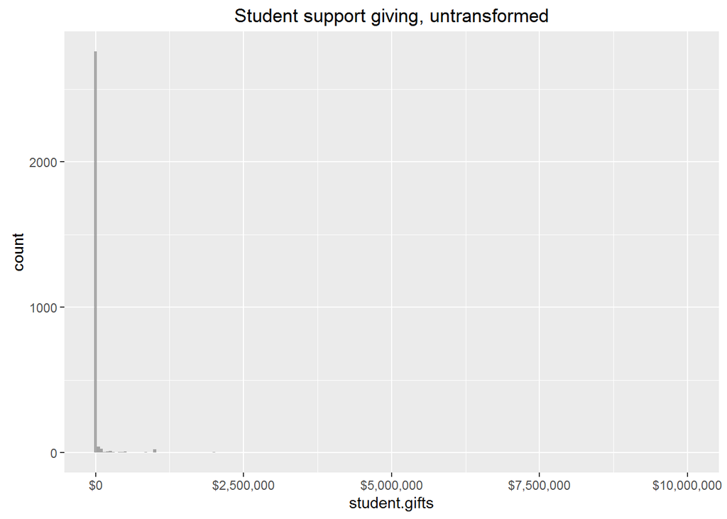

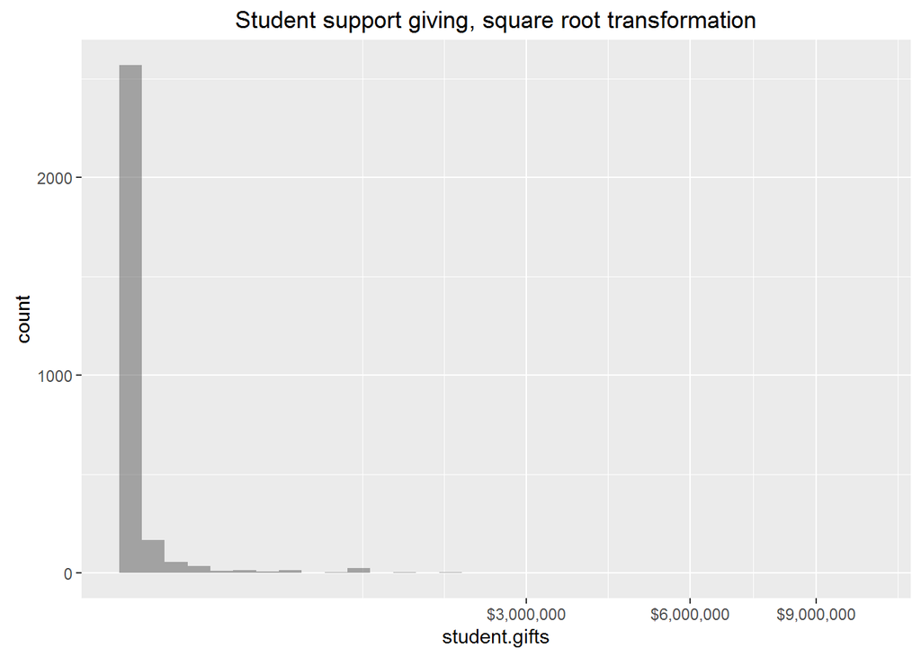

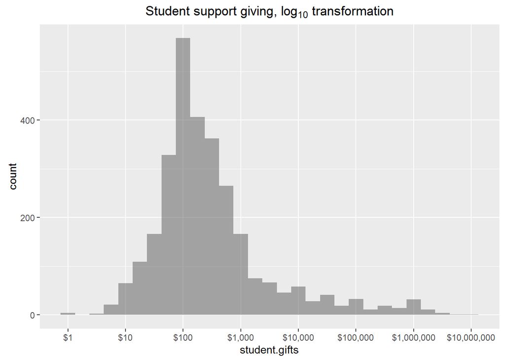

As usual, the $\text{log}_{10}$ transformation looks good. It does require dropping non-donors; one thought is to fit an explanatory model only to (a random sample of) those people who have made gifts and make predictions for the rest of the population. Of course, there’s no particular reason to think donors and non-donors are comparable, but it’s a starting point.

```r
mdat <- mdat %>% mutate(student.gifts.lt = log(student.gifts, base=10), lt.giving.lt = log(lt.giving, base=10))
ggdat <- mdat %>% filter(student.gifts > 0)
```

# Exploration

Exploring the factors and covariates. All plots exclude non-donors:

| spouse | count | mean.giving |
| --- | --- | --- |
| 0 | 21009 | 336.22 |
| Married | 32728 | 2356.69 |
| Married to Booth Alum | 2658 | 3584.99 |
| Married to UC Alum | 1070 | 7706.36 |

| spouse | donor.count | mean.donor.giving |
| --- | --- | --- |
| 0 | 915 | 7719.72 |
| Married | 1712 | 45052.51 |
| Married to Booth Alum | 220 | 43313.14 |
| Married to UC Alum | 76 | 108497.40 |

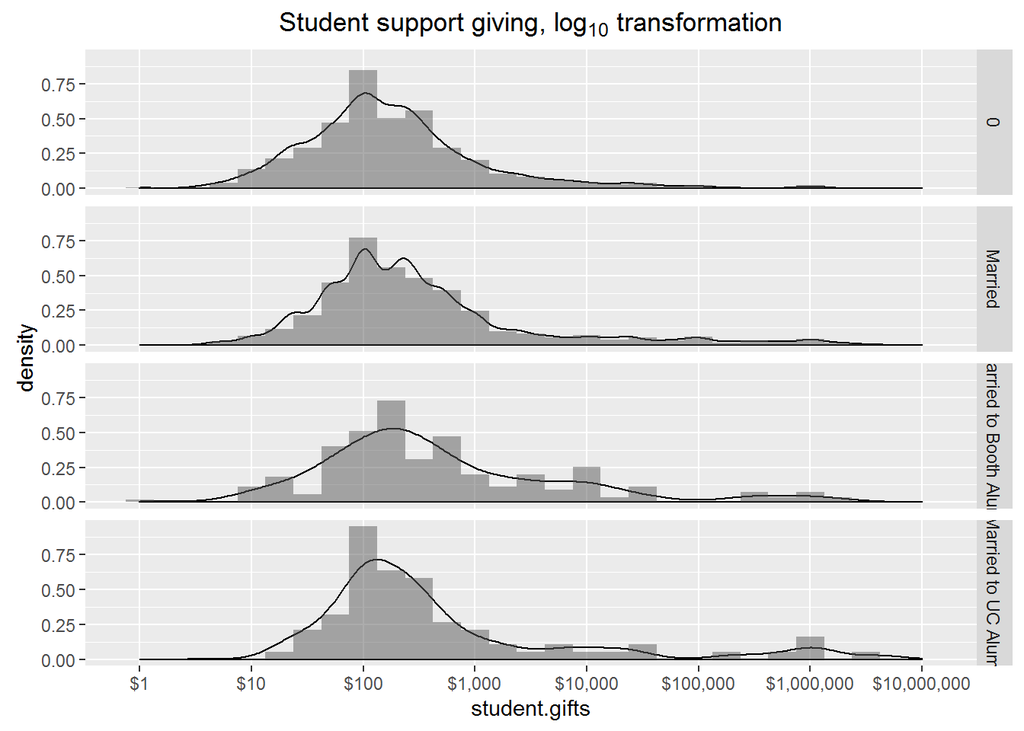

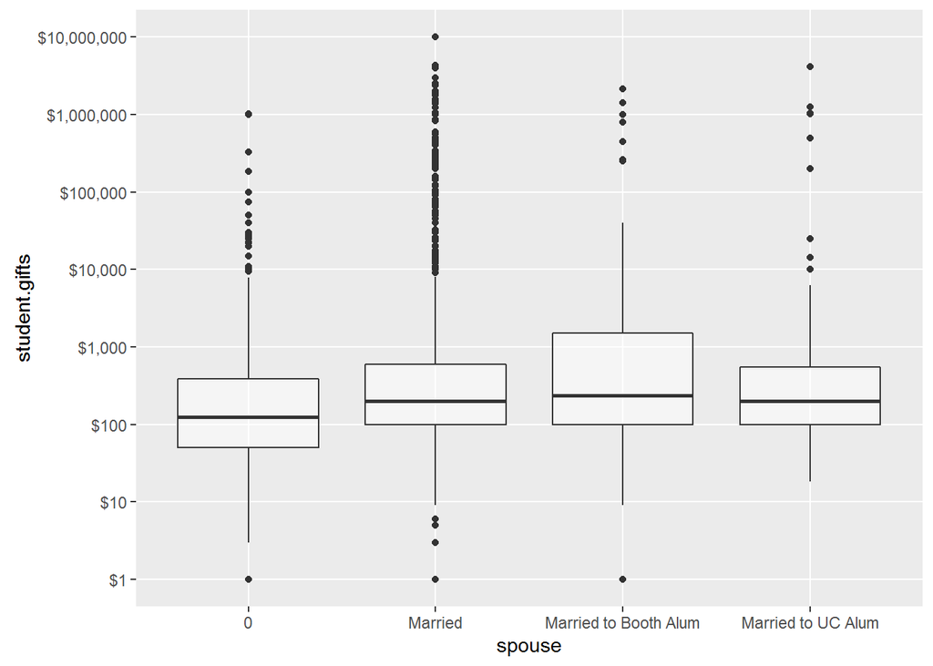

Ignoring other covariates, married donors are more generous than unmarried ones. On to the numerical variables.

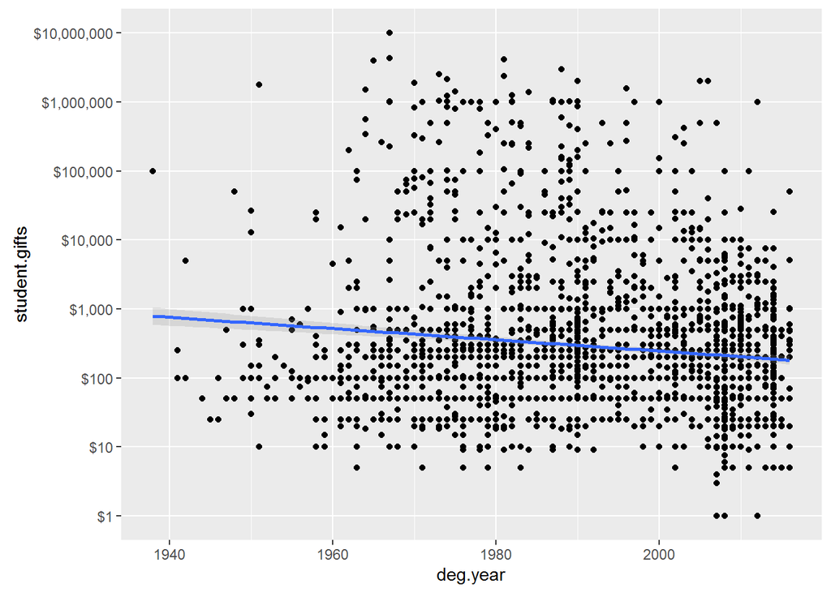

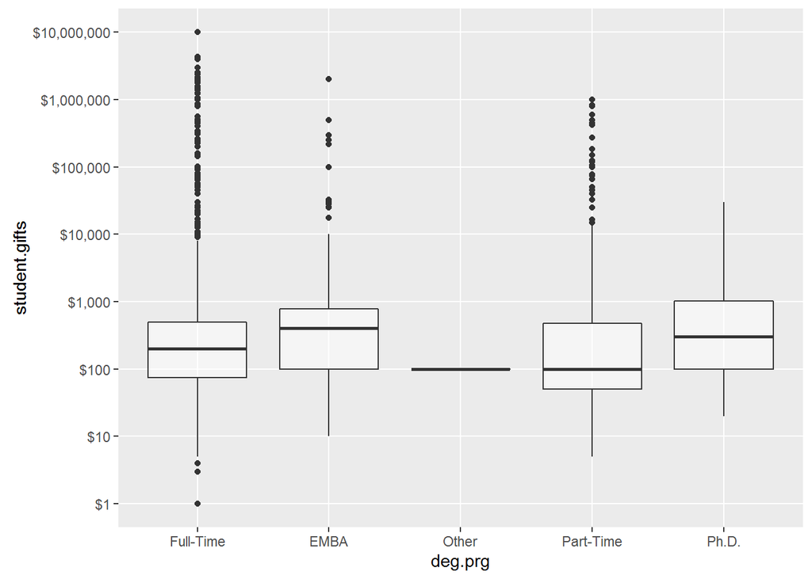

Younger alumni have given less, which follows given their lower lifetime earnings. Part-time alumni appear to be less generous than the rest.

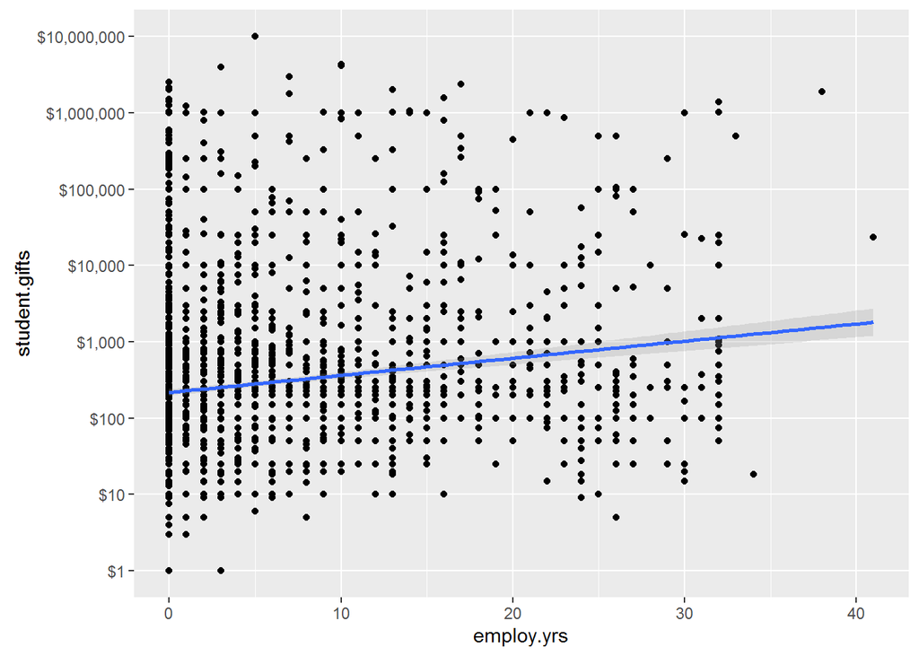

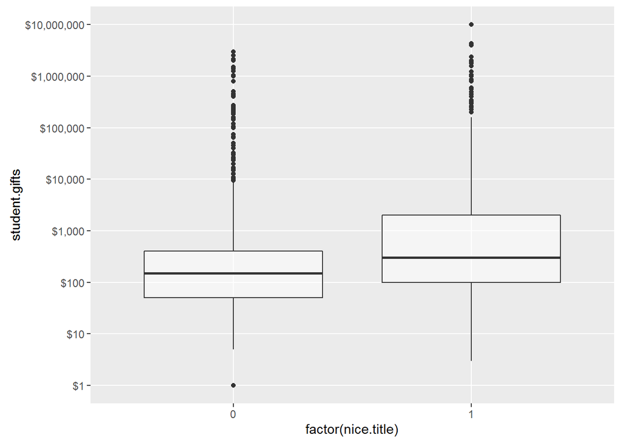

Being employed longer and having a fancy job title is associated with increased giving to student causes, ignoring other covariates. (I’m going to stop writing that but it’s assumed for the rest.)

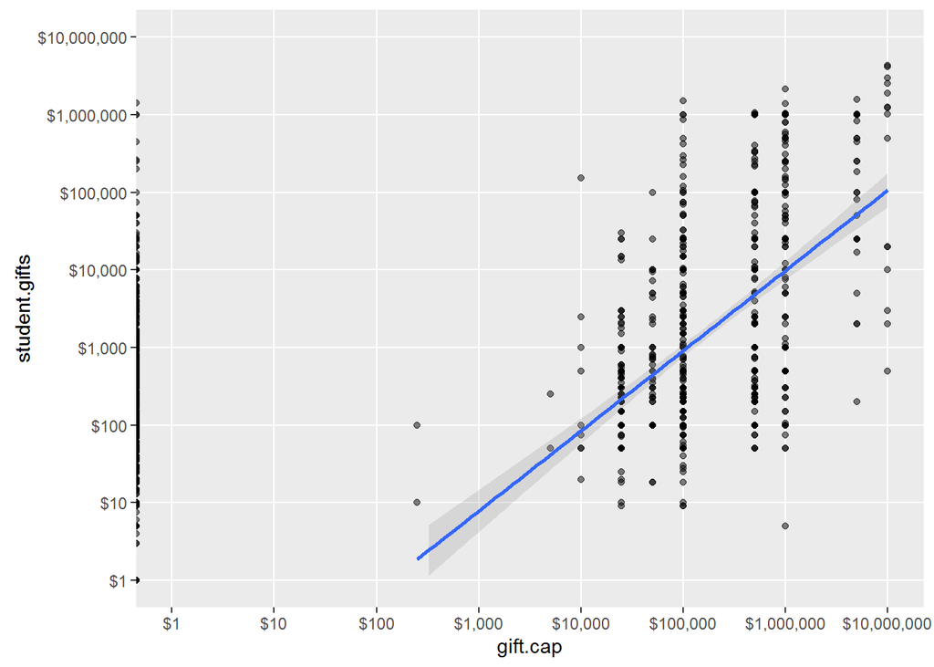

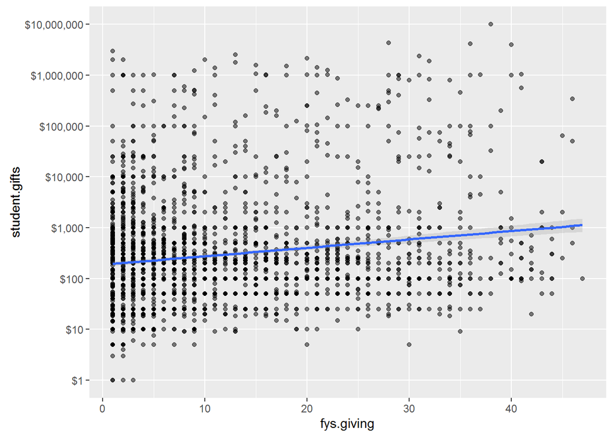

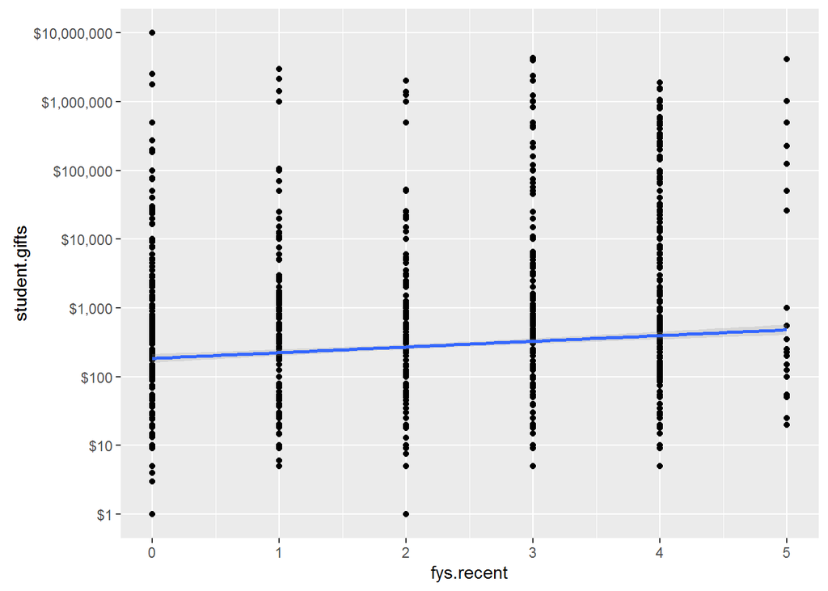

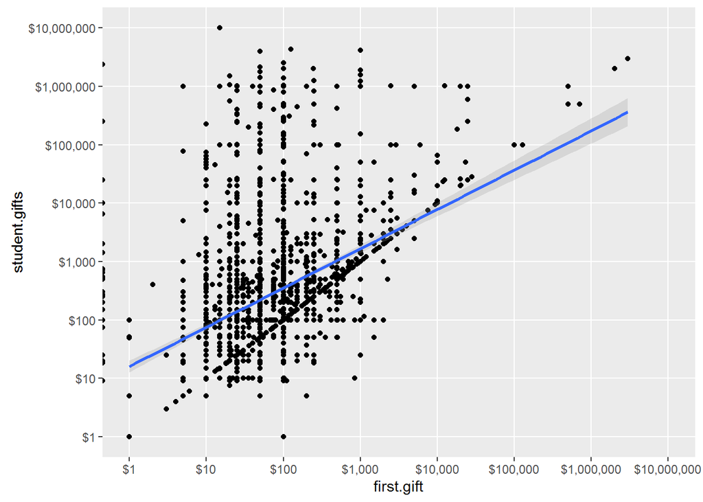

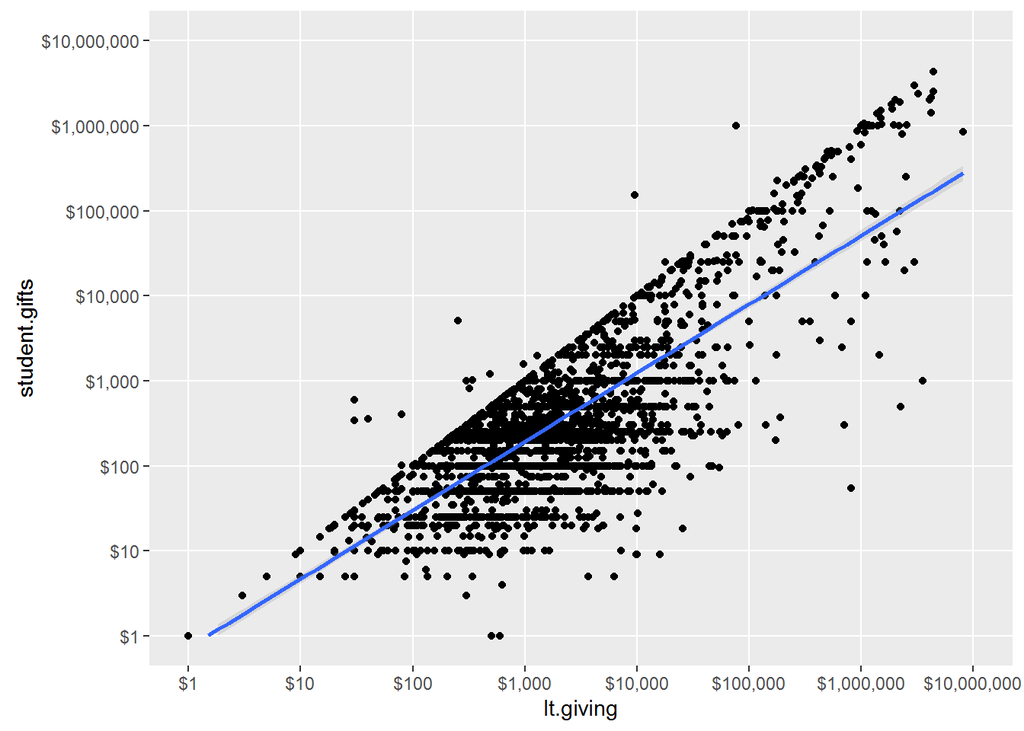

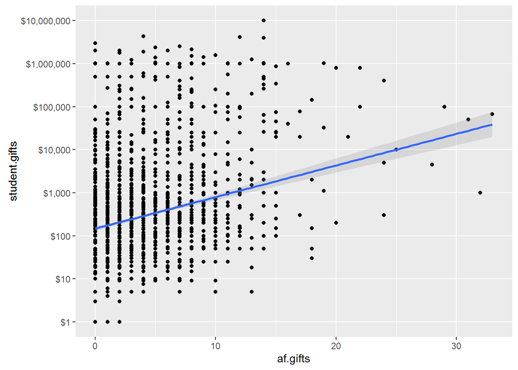

Previous giving and gift capacity are strongly associated with other giving behaviors, as has been repeatedly found in the past. In particular, note the correlation between first gift and student giving amounts – there are a few interesting patterns apaprent, such as the cluster of points around $x=y$ and shrinking variances as first gift amounts increase.

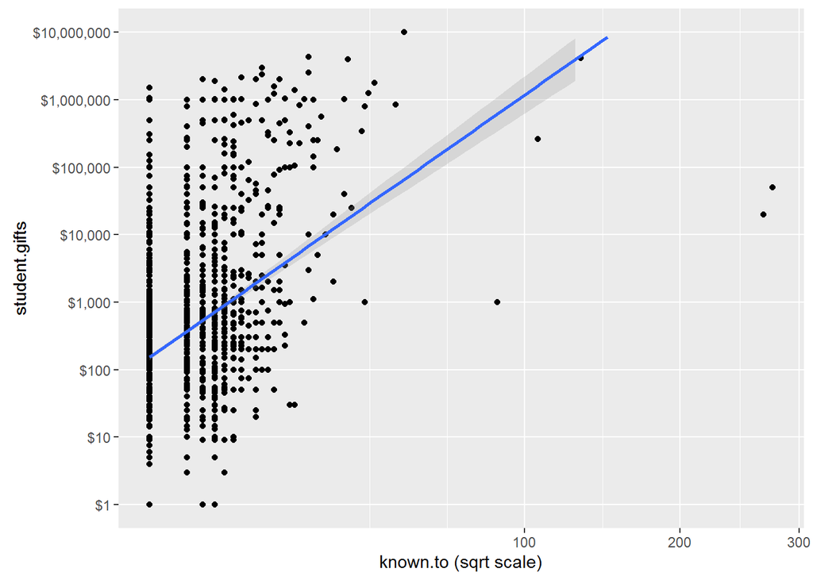

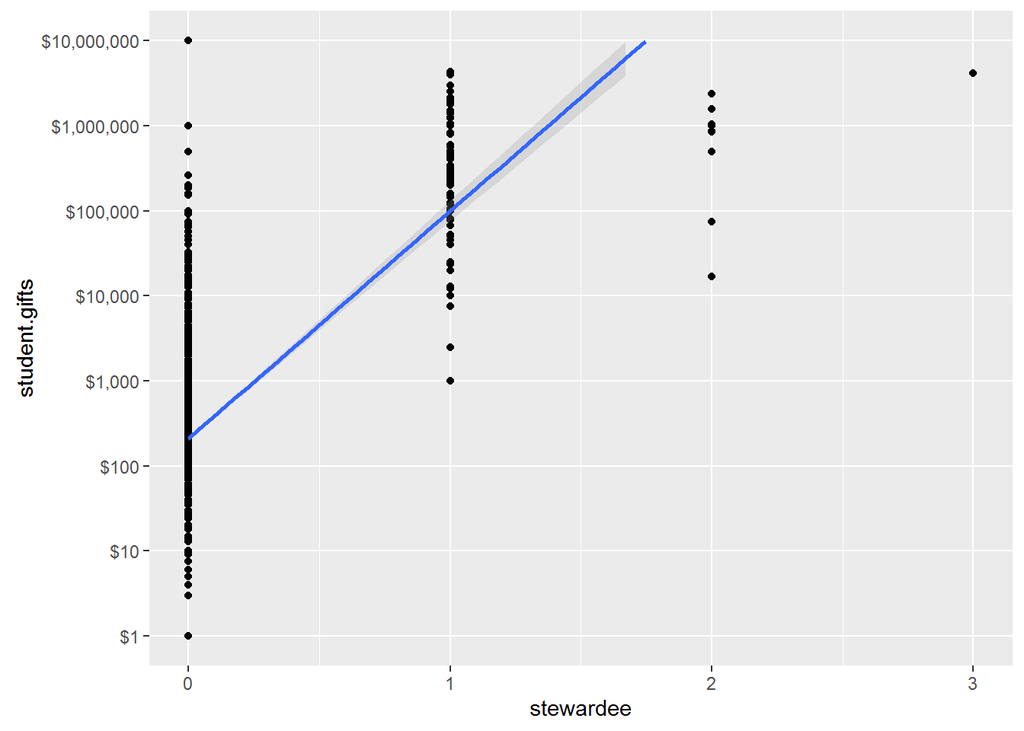

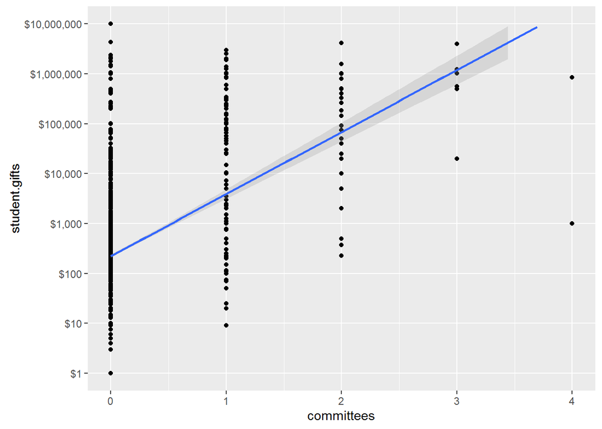

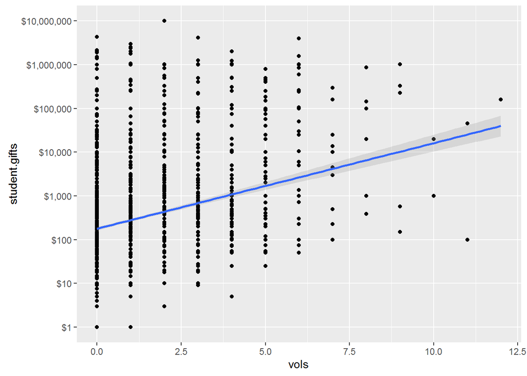

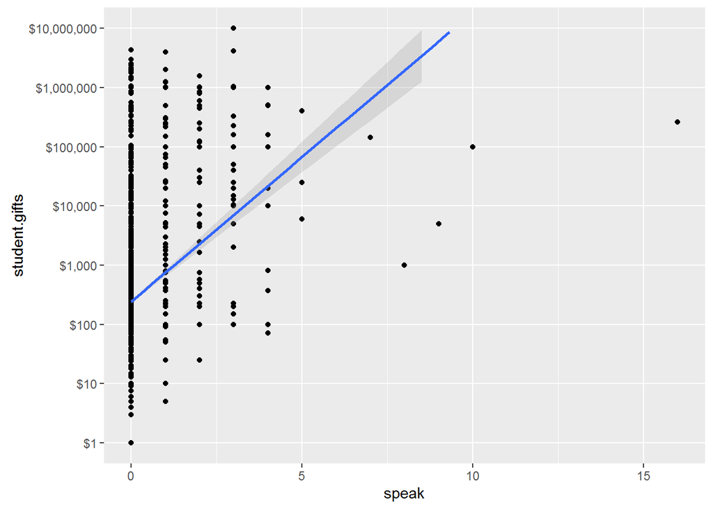

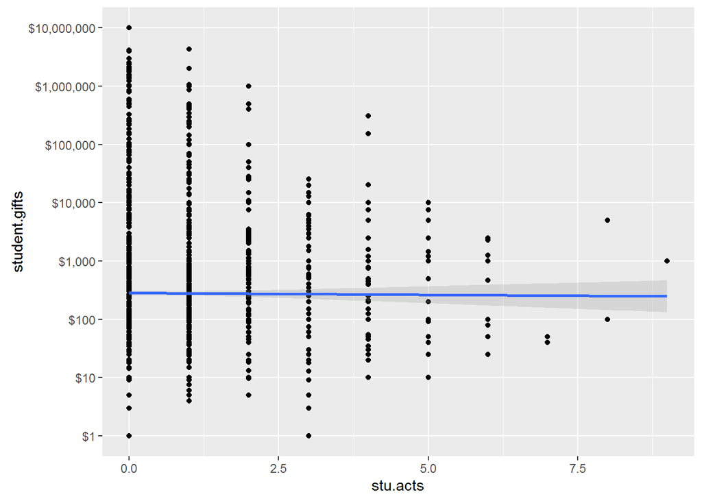

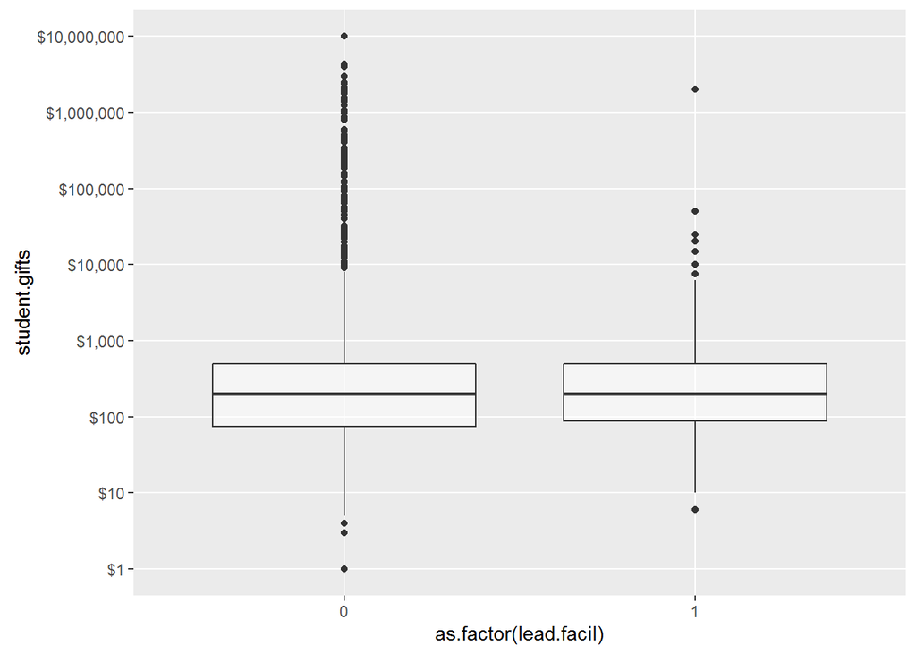

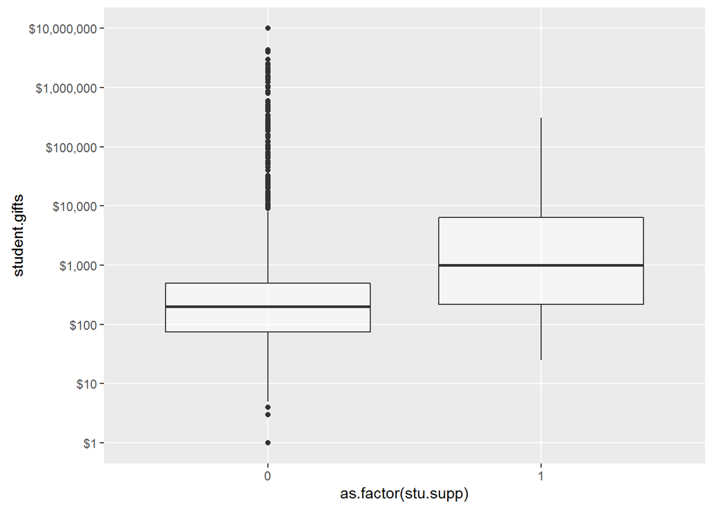

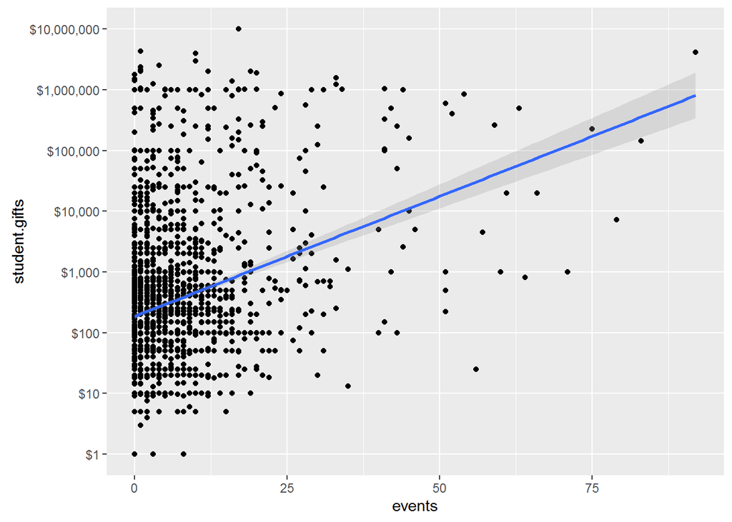

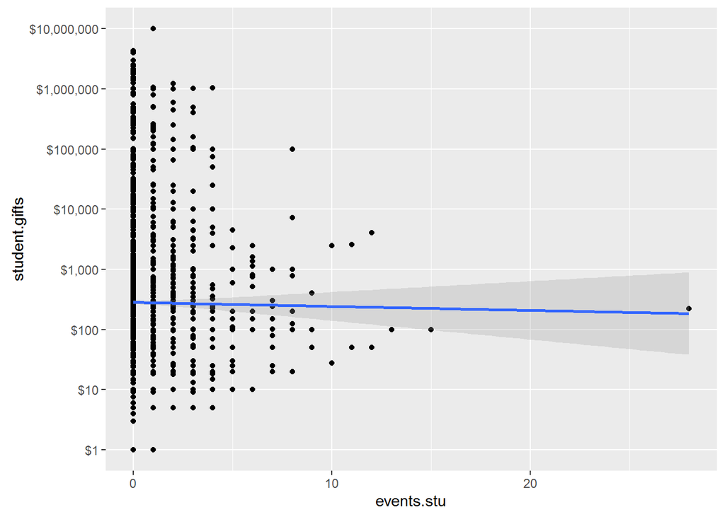

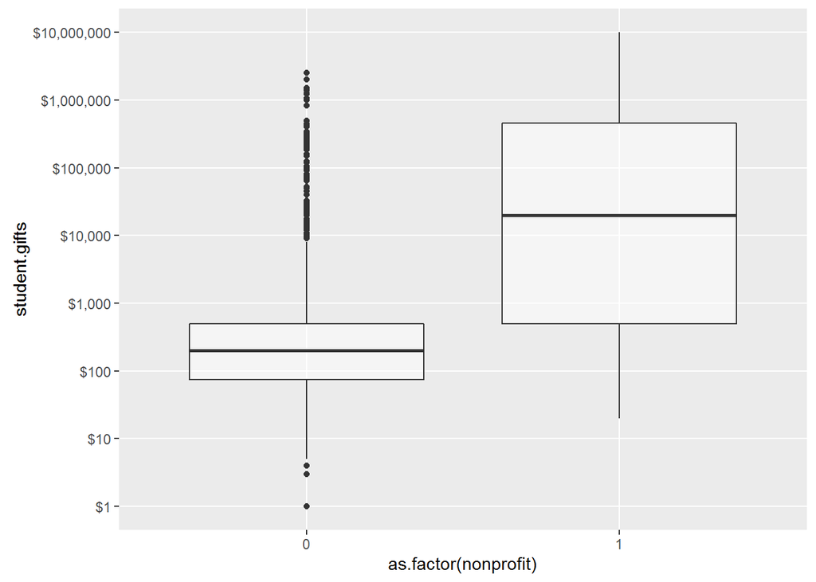

A bit of a mixed bag here: people who are involved as *students* are not more likely to be donors, but those who are involved as alumni are. In particular, note the difference between student and alumni event attendance. Many of these are counts and should be transformed (sqrt) if used in a lm or glm.

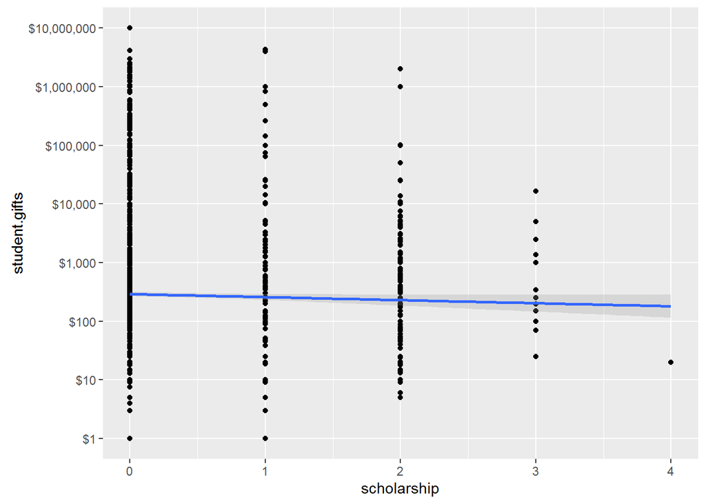

And here’s the big surprise: no association, or even slightly negative, between receiving scholarships and giving to student causes. I expect that receiving scholarships is associated with age, for example, so there might still be a story there.

# Variable importance

Random forests (Breiman) are an established ensemble method for classification and regression. We can see which (untransformed) variables are selected by the model as a proxy for variable importance.

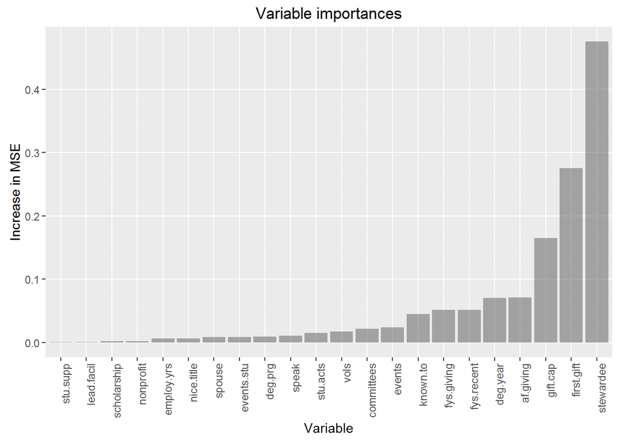

This measure of variable importance gives the percent change in MSE after removing the variable. Unsurprisingly, being a current stewardee of a scholarship fund is the best predictor, followed by first gift size and gift capacity. Try again without these three indicators:

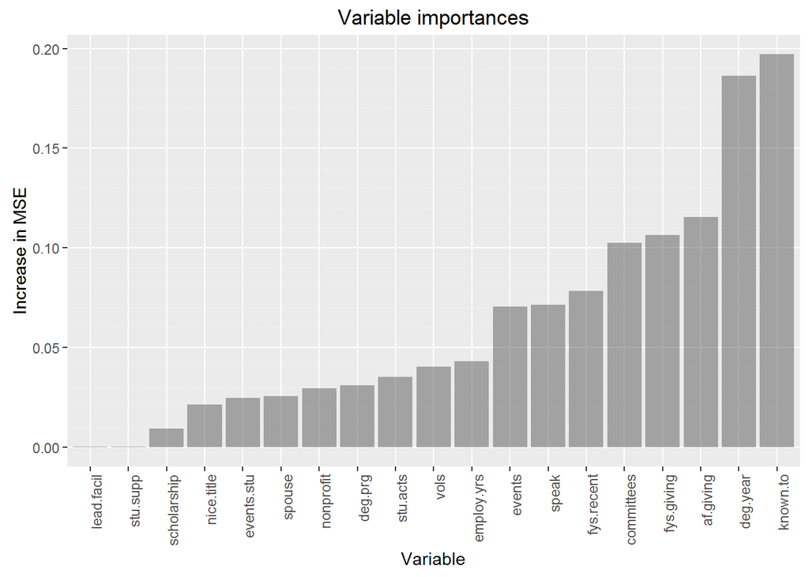

Now the engagement indicators really pop. For modeling, `stewardee` and `gift.cap` should certainly be dropped, and `first.gift` is borderline, as it’s perfectly correlated with the response variable `student.gifts` in a subset of cases as seen during exploration above.